# Explotació resultats simulació - AMB

IERMB

20 abril, 2021 - 15:02

Tots els resultats d’aquest document fan referència a la simulació amb dades per l’a ciutat de Barcelona’AMB. Les variables de rendes contemplen la transferència del IMV per les llars aplicables.

Referències simulació

| Variable | Valor |
| --- | --- |
| Territori | AMB |
| Escenari | U5 |
| n | 5281 |
| Iteracions | 1e+05 |
| Data simulació | 20/04/21 |
| Font dades atur | EPA 2020 |
| Referència temp. ERTOS | Desembre |
| Taxa d’atur projectada | 15.1 |
| Proporció atur amb prestació | 29.6 |
| Població afectada per ERTO | 28.3 |
| Assignació mesos a l’atur | probabilística |
| Base dades renda | EMCV |

### Taula 1.

Renda anual neta mitjana per llar, persona i unitat de consum (euros). AMB, 2016-2017, 2017-2018, 2018-2019 i estimacions 2020.

| Renda.anual.neta.mitjana | 16-17 | 17-18 | 18-19 | sim2020 |
| --- | --- | --- | --- | --- |
| per llar | 33251 | 34292 | 34757 | 32517.4 |
| per persona | 13628 | 14124 | 14303 | 13381.3 |
| per unitat de consum | 20133 | 20814 | 21071 | 19667.3 |

### Taula 2.

Variació relativa en la mitjana dels ingressos equivalents de la població segons decils de renda

| Decil | 2016-2017 | 2017-2018 | 2018-2019 | sim2020 | Variació |
| --- | --- | --- | --- | --- | --- |
| 1 | 4980.7 | 4926.3 | 4862.9 | 4279.0 | -12.0 |
| 2 | 8994.1 | 9303.9 | 9498.8 | 8334.8 | -12.3 |
| 3 | 11435.9 | 11787.1 | 12388.9 | 11164.2 | -9.9 |
| 4 | 13700.9 | 14340.0 | 14971.6 | 13680.2 | -8.6 |
| 5 | 15912.3 | 16571.7 | 17184.3 | 15885.9 | -7.6 |
| 6 | 18673.8 | 19407.0 | 19839.6 | 18284.1 | -7.8 |
| 7 | 21880.4 | 22714.5 | 22735.8 | 21403.4 | -5.9 |
| 8 | 25934.2 | 26823.4 | 26820.8 | 25180.0 | -6.1 |
| 9 | 31665.3 | 32691.8 | 32956.2 | 31078.0 | -5.7 |
| 10 | 48930.7 | 50554.3 | 51211.2 | 47543.5 | -7.2 |

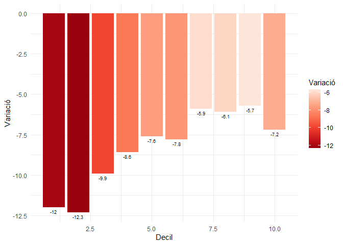

### Taula 3.1.

Índex de Gini

| Any | Valor | Sèrie |
| --- | --- | --- |
| 1985 | 39.7 | ECVHP |
| 1990 | 34.9 | ECVHP |
| 1995 | 32.5 | ECVHP |
| 2000 | 31.3 | ECVHP |
| 2006 | 29.3 | ECVHP |
| 2011 | 32.7 | ECVHP (base ECV 2004) |
| 16-17 | 32.9 | EMCV |
| 17-18 | 32.3 | EMCV |
| 18-19 | 32.1 | EMCV |
| sim2020 | 33.4 | Sim - EMCV |

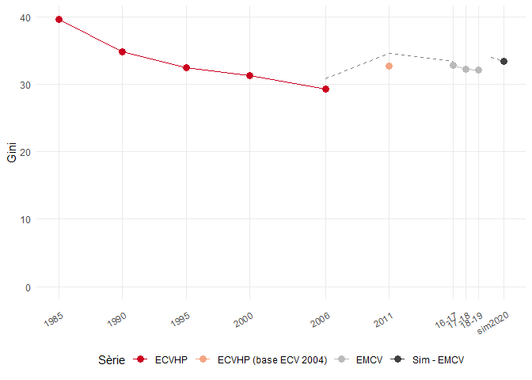

### Taula 3.2.

Raons de desigualtat entre decils de renda

| Raons | 1985 | 1990 | 1995 | 2000 | 2006 | 2011 | 16-17 | 17-18 | 18-19 | sim2020 |
| --- | --- | --- | --- | --- | --- | --- | --- | --- | --- | --- |
| P90/50 | 2.7 | 2.5 | 2.1 | 2.1 | 1.9 | 2.0 | 2.0 | 2.0 | 2.1 | 2.1 |
| P50/10 | 2.5 | 2.1 | 2.0 | 1.9 | 2.2 | 2.3 | 2.2 | 2.2 | 2.5 | 2.5 |

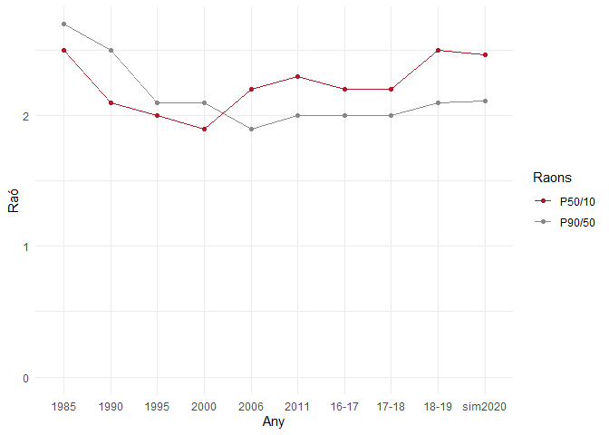

### Taula 4.1

Taxes de risc de pobresa segons intensitat

| indicador | 2011 | 16-17 | 17-18 | 18-19 | sim2020 |
| --- | --- | --- | --- | --- | --- |
| moderada (60%) | 20.0 | 20.8 | 21.3 | 20.0 | 21.4 |
| severa (40%) | 7.6 | 7.2 | 7.6 | 9.1 | 9.8 |
| extrema (30%) | 5.2 | 4.7 | 4.8 | 5.3 | 6.2 |

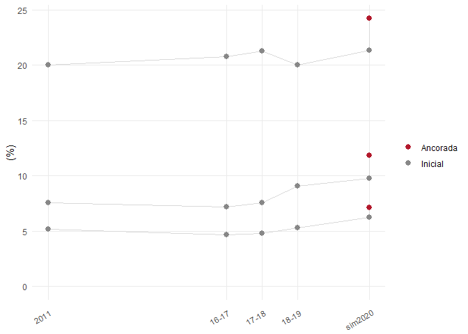

### Taula 4.2.

Intensitat de risc de pobresa

> % distance to poverty threshold: The indicator is calculated as the distance between the median equivalised total net income of persons below the at-risk-of-poverty threshold and the at-risk-of-poverty threshold itself, expressed as a percentage of the at-risk-of-poverty threshold. This threshold is set at 60 % of the national median equivalised disposable income of all people in a country and not for the EU as a whole.

| indicador | 16-17 | 17-18 | 18-19 | sim2020 |
| --- | --- | --- | --- | --- |
| Intensitat de risc de pobresa | 0.225 | 0.236 | 0.293 | 0.321 |
| Llindar | NA | NA | 11052.900 | NA |
| Mediana IE pobres | NA | NA | 7814.540 | NA |

### Taula 4.3

Pobresa ancorada (2018-2019) segons diferent intensitat. Llindar 2018-2019

| indicador | 2018-2019 | sim2020 |
| --- | --- | --- |
| Ancorada-Pobresa moderada (60% mediana) | 20.0 | 24.2 |
| Ancorada-Pobresa severa (40% mediana) | 9.1 | 11.9 |
| Ancorada-Pobresa extrema (30% mediana) | 5.3 | 7.1 |

### Taula 5.

Canvis a la pobresa estimada (60% mediana) segons característiques sociodemogràfiques

| var | categories | 17-18 | 18-19 | sim2020 | ANC2020 |
| --- | --- | --- | --- | --- | --- |
| sexe | Homes | 21.3 | 19.9 | 21.2 | 24.5 |
| sexe | Dones | 21.2 | 20.1 | 21.6 | 23.9 |
| edat | 0-15 anys | 26.4 | 27.0 | 30.6 | 33.4 |
| edat | 16-34 anys | 26.1 | 21.5 | 23.3 | 27.0 |
| edat | 35-64 anys | 18.6 | 18.2 | 20.6 | 22.5 |
| edat | 65 i més anys | 17.8 | 16.7 | 12.8 | 17.0 |
| nacionalitat | Espanya | 15.2 | 12.7 | 12.6 | 15.4 |
| nacionalitat | Resta del món | 41.8 | 39.6 | 44.1 | 47.4 |
| llars | Unipersonal < 65 anys | 23.2 | 26.8 | 29.7 | 31.8 |
| llars | Unipersonal > 65 anys | 33.0 | 33.1 | 27.0 | 32.4 |
| llars | sense infants | 14.5 | 13.1 | 13.7 | 16.4 |
| llars | amb infants | 26.5 | 24.6 | 27.6 | 30.3 |
| csp | Directius i professionals | 8.1 | 9.2 | 8.3 | 9.8 |
| csp | Ocupacions intermèdies | 12.2 | 10.3 | 10.1 | 12.2 |
| csp | Petits empresaris i autònoms | 31.4 | 27.8 | 27.3 | 29.5 |
| csp | semiqualificats de serveis | 25.8 | 21.9 | 25.9 | 29.5 |
| csp | semiqualificats o de rutina | 26.4 | 24.8 | 25.8 | 29.7 |
| csp | ALLD/NTM | 33.2 | 30.1 | 28.1 | 32.9 |

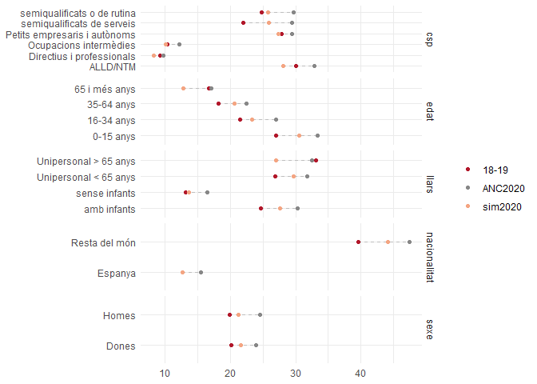

### Taula 6.

Proporció mitjana de la renda anual (neta) de les llars que es destina a les despeses fixes de l’habitatge (sense amortització), segons règim de tinença de l’habitatge.

| RTL | 2016-2017 | 2017-2018 | 2018-2019 | sim2020 |
| --- | --- | --- | --- | --- |
| Propietat totalment pagada | 11.1 | 10.8 | 9.8 | 10.4 |
| Propietat amb pagaments ajornats | 14.7 | 13.6 | 13.5 | 15.2 |
| En lloguer o relloguer | 40.4 | 40.4 | 40.5 | 44.6 |
| Un altre tipus de règim de tinença | 13.1 | 16.5 | 14.1 | 16.6 |
| Total | 20.4 | 20.8 | 20.9 | 23.0 |

### Taula 7.

Taxa de sobrecàrrega despeses habitatge (sense amortització) amb diferents llindars

| perc | RTL | 16-17 | 17-18 | 18-19 | sim2020 |
| --- | --- | --- | --- | --- | --- |
| >40% | pagada | 2.2 | 1.8 | 1.4 | 1.7 |
| >40% | pagaments | 3.6 | 3.6 | 3.3 | 4.4 |
| >40% | lloguer | 37.3 | 35.8 | 34.9 | 46.6 |
| >40% | altres | 5.4 | 7.5 | 5.3 | 9.2 |
| >60% | pagada | 1.6 | 1.2 | 0.8 | 0.8 |
| >60% | pagaments | 1.5 | 1.4 | 1.1 | 1.8 |
| >60% | lloguer | 16.7 | 18.4 | 18.1 | 22.0 |
| >60% | altres | 4.5 | 7.0 | 3.9 | 7.3 |

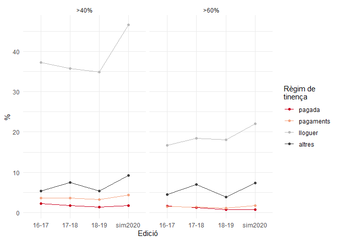

### Taula 8.

Taxa de risc de pobresa (60% mediana) abans i després del IMV

El llindar de referència fa servir les dades després de la injecció del IMV.

| TRP | abans | despres |
| --- | --- | --- |
| trp30 | 6.3 | 6.2 |
| trp40 | 9.8 | 9.8 |
| trp60 | 21.4 | 21.4 |